# hw03-ISHIAKAWA

Ishikawa Chiharu

2014年10月21日

## 課題１

- 階乗を計算する関数を作りなさい。

*1.関数の名前は “hw03.factorial”とし、引数はxとする。* 2.戻り値は*return*である。後でかけ算を行うため、はじめに1を割り当てる。 * 3.x<0の場合、計算しないよう設定。（xが負の値をとらないと仮定しているため） * 4.x=oの場合は、x!=1のため、1を返する。

```r
hw03.factorial <- function(x){
  # 引数：x (整数)
  # 戻り値：result

  result <- 1 # 戻り値を1と定義する

　#x<0の場合

  if(x < 0){       # 引数xが0より小さい場合
    # error messageとして以下を表示
    print("The argument must be greater than ZERO.")
    }

  #x=0の場合

  else if(x == 0){ # xが０の場合、
    return(1) # 戻り値は１に設定
  }

  #x>0の場合
  else{            # 引数が０よりも大きい場合は
    for(i in x:1){
      result <- result * i # "i" と １つ前の値ををかける
    }
    return(result) #戻り値
  }
}
```

確認のため、Rの内蔵関数(`factorial`)と自作関数の結果を比較する。

```r
# hw03.factorialと and factorial in R間の比較
factorial(6) == hw03.factorial(6)
```

```
## [1] TRUE
```

### 課題２

*自分で作った階乗の関数を利用して、組み合わせを計算する関数を作りなさい。

- 1.組み合わせを演算するユーザー定義関数をhw03.chooseとし、因数はnとkにする。これはn個の中から、k個を選ぶとする
- 2.nとkの場合分けを行う。
- 1.kがnより大きい場合、0を返す。if( (a<k)の部分 )
- 2.それ以外のの場合は組合せの演算を行う。(`else`の部分) 組合せの公式は$\begin{pmatrix} n \\ k \end{pmatrix} =\frac { n! }{ k!(n-k)! }$である。べき乗の演算は`hw03.factorial()`で処理する。
- 3. 結果は*result*に書き込まれ、最後に*result*の値を返す。(`return(result)`の部分)

```r
hw03.choose <- function(n, k){
  # 引数: n, k
  # 戻り値：result

  if(n < k){  # kがnよりも大きい場合
    return(0) # 戻り値"0"
  }

  else{       #n が kよりも大きい場合
    #組み合わせの関数
    result <- hw03.factorial(n) / (hw03.factorial(k) * hw03.factorial(n-k))

    return(result) #  resultを返す
  }
}
```

```r
#function, hw03.factorialと factorial の比較
choose(8, 2) == hw03.choose(8, 2)
```

```
## [1] TRUE
```

### 課題３

- 自分で作った組み合わせの関数を利用して、二項分布の確率質量を求める関数を作りなさい。
- 1. 二項分布の確率質量を求める定義関数を*hw03.dbinom*とし、因数は*x*、*n*、*p*とする。*x*は成功回数であり、*n*は試行回数、*p*は成功確率である。
- 2. 確率質量を求めるために$f\left( x \right) =\begin{pmatrix} n \\ x \end{pmatrix}{ p }^{ x }{ (1-p) }^{ n-x }\quad (x=0,1,2,...,n)$の演算を行う。組合せは問題２の`hw03.choose`を利用する。
- 3. 最後に結果を*result*とし、戻り値とする。

```r
hw03.dbinom <- function(x, n, p){
  # 引数: x - 成功回数 (整数)
  #            n - ベルヌーイ試行回数 (整数)
  #            p - 成功の確率 (整数)
  # 戻り値: 結果

    # 二項確立を計算
    result <- hw03.choose(n, x) * p^x * (1-p)^(n-x)

  return(result)
}
```

最後にRの内蔵関数(`dbinom`)と自作関数の（hw03.dbinom）結果を比較する。

```r
# 比較
dbinom(3, 100, 0.3) == hw03.dbinom(3, 100, 0.3)
```

```
## [1] FALSE
```

比較すると、内臓関数と自作関数の値が一致しないため、個別的に検証する。

```r
dbinom(3, 100, 0.3)
```

```
## [1] 4.117027e-12
```

```r
hw03.dbinom(3, 100, 0.3)
```

```
## [1] 4.117027e-12
```

### 課題４

- 自分で作った二項分布の関数を使い、n が 2, 3, 5, 10 の場合について、確率質量を図示しなさい。p の値については任意とする。ただし、2 つ以上の p で図を作りなさい。その際、forループを少なくとも 1 回使いなさい。

最初に二項分布の確率質量を書き込むためのデータフレームを作成する。ここでは最終的に使うデータフレーム*final.data.frame*とループ文内で使用する*temp.data.frame*の２つを作成する。*temp.data.frame*は第１行のみを使い上書きするため欠損値(NA)で作成したが、*final.data.frame*は`rbind()`コマンドを用いて結合させるためNULLで設定する。

```r
# ループ文内で使用するデータフレームを"temp.data.frame" (Temporary data)とする。
temp.data.frame <- data.frame(p=NA, n=NA, x=NA, result=NA)
# 最終的に作成するデータフレーム"final.data.frame" (Full data)とする。
final.data.frame <- data.frame(p=NULL, n=NULL, x=NULL, result=NULL)
```

成功確率*p*, 試行回数*n*, 成功回数*x*、それぞれに対してループを使うため３つのfor文を用いる。これらは独立しているわけではなく、三重構造になる。

```r
for(p in c(0.5, 0.8)){         #  p = 0.5 p = 0.8　と指定し、ループ
  for(i in c(2, 3, 5, 10)){    #  n = 2, 3, 5, 10　と指定し、ループ
    for(j in 0:i){             #  x = 0 ~ n　までループ

      # for()内の p, n, x, に 代入
      temp.data.frame[1, ] <- c(paste("p =", p), paste("n =", i), j, hw03.dbinom(j, i, p))

      # 2つのデータを結合
      final.data.frame <- rbind(final.data.frame, temp.data.frame)
    }
  }
}
```

この過程によって生成された*final.data.frame*は中身は以下のようである。

```r
#  "final.data.frame"の最初の６つのデータを表示
head(final.data.frame)
```

```
##         p     n x result
## 1 p = 0.5 n = 2 0   0.25
## 2 p = 0.5 n = 2 1    0.5
## 3 p = 0.5 n = 2 2   0.25
## 4 p = 0.5 n = 3 0  0.125
## 5 p = 0.5 n = 3 1  0.375
## 6 p = 0.5 n = 3 2  0.375
```

```r
# "final.data.frame"の最後の６つのデータを表示
tail(final.data.frame)
```

```
##          p      n  x       result
## 43 p = 0.8 n = 10  5 0.0264241152
## 44 p = 0.8 n = 10  6  0.088080384
## 45 p = 0.8 n = 10  7  0.201326592
## 46 p = 0.8 n = 10  8  0.301989888
## 47 p = 0.8 n = 10  9  0.268435456
## 48 p = 0.8 n = 10 10 0.1073741824
```

*final.data.frame*の中身は数値データではなく文字データとして書き込まれているため、このまま`ggplot`を用いて４つのグラフを表示させると*n=10*, *n=2*, *n=3*, *n=5*の順番で表示される。これを避けるために*final.data.frame*の*n*列のデータをfactor型へ変換し、順序付けする。

```r
# Factoring the column, "n", in order to order the plots
final.data.frame$n <- factor(final.data.frame$n,
                             levels = c("n = 2", "n = 3", "n = 5", "n = 10"))
```

結果グラフを表示する。成功確率(*p*)に分けて作図するため、同一データフレーム内の異なる行のデータ(1 ~ 24行：*p = 0.5*, 24 ~ 48行：*p = 0.8*)を用いる。

```r
# Setting data set for plotting
prob4.bar1 <- ggplot(data=final.data.frame[1:24, ])
prob4.bar2 <- ggplot(data=final.data.frame[25:48, ])
```

上記した基本セットにオプションを付けて表示する。

（`ggplot`での日本語表記が文字化けするため、宋財泫さんのやり方を大部分参考にしました）

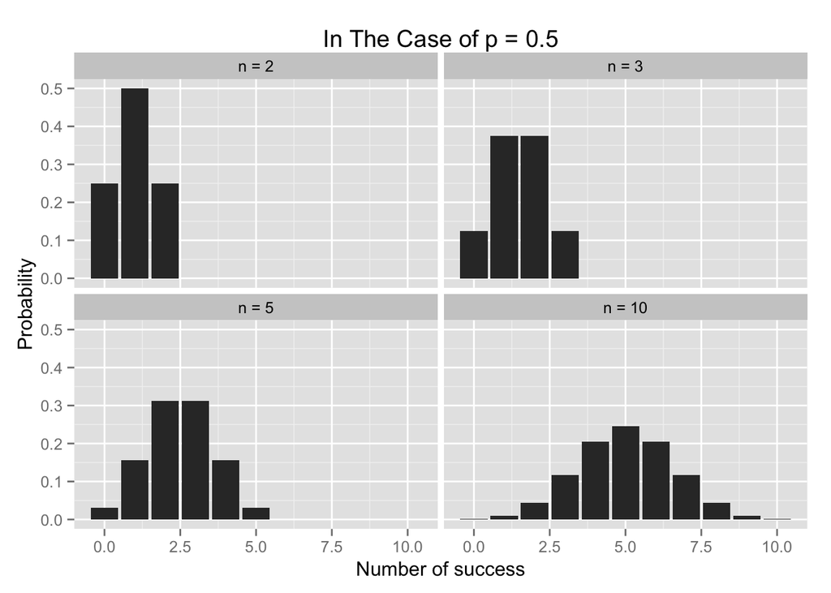

```r
# Display the plot of "p = 0.5" with dividing by "n"
prob4.bar1 + geom_bar(aes(x = as.integer(x), y = as.numeric(result)), stat="identity") +
             facet_wrap(~n) + ylab("Probability") + xlab("Number of success") +
             ggtitle("In The Case of p = 0.5")
```

以上は*p = 0.5*の場合の二項分布の確率質量である。

続いて、*p = 0.8*の場合の確率質量の棒グラフを表示する。

[figure not shown]

```r
# Display the plot of "p = 0.8" with dividing by "n"
prob4.bar2 + geom_bar(aes(x = as.integer(x), y = as.numeric(result)), stat="identity") +
             facet_wrap(~n) + ylab("Probability") + xlab("Number of success") +
             ggtitle("In The Case of p = 0.5")
```